# Ripley’s K, with SF and Rmarkdown

Hi all,

First thanks for the patience in class while we tried to fix the “projection” problem on site. Here I exprore another option of having the similar analysis as before but with the `sf` package.

The reason for all of this is that R is a very useful, diverse and dynamic programing language in which you can do *a lot* of things thanks to lovely people that spend their time creating functions and packages of such functions (such as `sf` and `sp`) so we can do comlex analysis simply. The downside of this is that not everything in R has been 100% checked by a central organization. There is a good amount of checking (specially by “The Comprehensive R Archive Network” [CRAN](https://cran.r-project.org/) ). Even with these some people stop working on their packages and new packages emerge. They try their best to make them all compatible but it doesn’t always work.

I do this on an [R Markdown](http://rmarkdown.rstudio.com) Notebook. It allows both writing notes and having code (on chunks). When you execute code within the notebook, the results appear beneath the code.

```r
# install.packages('dplyr')
library(dplyr)
head(cars)
```

|  | speed | dist |
| --- | --- | --- |
| 1 | 4 | 2 |
| 2 | 4 | 10 |
| 3 | 7 | 4 |
| 4 | 7 | 22 |
| 5 | 8 | 16 |
| 6 | 9 | 10 |

## Basic R functions and concepts

R is an **object-oriented programming**, this means that everything here are objects. Objects can by of different types (`classes`). They can be numbers, text (character), TRUE or FALSE (`boolean`) an many others.

Aggregations of objects can create lists, vectors, matrices or “dataframes”. We will mostly work with dataframes, vectors and lists.

### Very basic concepts that EVERYONE needs to understand

1. `<-` or `=` are operators (sit *between* objects such as `+` and `-`) that assigns whatever it is at the right of it to the object in the left. By executing an object you can “see” it.

```r
first_object = 4
first_object
```

```
## [1] 4
```

```r
first_object - 3
```

```
## [1] 1
```

```r
first_object + 3
```

```
## [1] 7
```

2. functions have objects ans inputs and as outputs

the `c()` function creates a vector

```r
vector_numbers = c(1,2, 3, 4, 5) # the c() function creates a vector
vector_numbers
```

```
## [1] 1 2 3 4 5
```

```r
max(vector_numbers)
```

```
## [1] 5
```

3. You will constantly have questions on (a) what functions should you use and (b) how funtions work.
1. Look at the seminars, frinds or Google. For (b) you should look at the R documentation files:

```r
help(max) # is equivalent to
```

```
## starting httpd help server ... done
```

```r
?max
```

(see the help file in the right)

In all documentations you have:

- The function you are working with
- Sn explanation of each input of the formula
- Some examples or use cases

If you want even more information, Google will always be your best ally

4. Differnt ways in which you can get a variable from a dataset

from the dataset `iris` we can pull his variable Sepal.Length using the operator `$`. or the funtion `pull`

```r
iris$Sepal.Length
```

```
##   [1] 5.1 4.9 4.7 4.6 5.0 5.4 4.6 5.0 4.4 4.9 5.4 4.8 4.8 4.3 5.8 5.7 5.4 5.1
##  [19] 5.7 5.1 5.4 5.1 4.6 5.1 4.8 5.0 5.0 5.2 5.2 4.7 4.8 5.4 5.2 5.5 4.9 5.0
##  [37] 5.5 4.9 4.4 5.1 5.0 4.5 4.4 5.0 5.1 4.8 5.1 4.6 5.3 5.0 7.0 6.4 6.9 5.5
##  [55] 6.5 5.7 6.3 4.9 6.6 5.2 5.0 5.9 6.0 6.1 5.6 6.7 5.6 5.8 6.2 5.6 5.9 6.1
##  [73] 6.3 6.1 6.4 6.6 6.8 6.7 6.0 5.7 5.5 5.5 5.8 6.0 5.4 6.0 6.7 6.3 5.6 5.5
##  [91] 5.5 6.1 5.8 5.0 5.6 5.7 5.7 6.2 5.1 5.7 6.3 5.8 7.1 6.3 6.5 7.6 4.9 7.3
## [109] 6.7 7.2 6.5 6.4 6.8 5.7 5.8 6.4 6.5 7.7 7.7 6.0 6.9 5.6 7.7 6.3 6.7 7.2
## [127] 6.2 6.1 6.4 7.2 7.4 7.9 6.4 6.3 6.1 7.7 6.3 6.4 6.0 6.9 6.7 6.9 5.8 6.8
## [145] 6.7 6.7 6.3 6.5 6.2 5.9
```

```r
# which is equivalent to
pull(iris, Sepal.Length)
```

```
##   [1] 5.1 4.9 4.7 4.6 5.0 5.4 4.6 5.0 4.4 4.9 5.4 4.8 4.8 4.3 5.8 5.7 5.4 5.1
##  [19] 5.7 5.1 5.4 5.1 4.6 5.1 4.8 5.0 5.0 5.2 5.2 4.7 4.8 5.4 5.2 5.5 4.9 5.0
##  [37] 5.5 4.9 4.4 5.1 5.0 4.5 4.4 5.0 5.1 4.8 5.1 4.6 5.3 5.0 7.0 6.4 6.9 5.5
##  [55] 6.5 5.7 6.3 4.9 6.6 5.2 5.0 5.9 6.0 6.1 5.6 6.7 5.6 5.8 6.2 5.6 5.9 6.1
##  [73] 6.3 6.1 6.4 6.6 6.8 6.7 6.0 5.7 5.5 5.5 5.8 6.0 5.4 6.0 6.7 6.3 5.6 5.5
##  [91] 5.5 6.1 5.8 5.0 5.6 5.7 5.7 6.2 5.1 5.7 6.3 5.8 7.1 6.3 6.5 7.6 4.9 7.3
## [109] 6.7 7.2 6.5 6.4 6.8 5.7 5.8 6.4 6.5 7.7 7.7 6.0 6.9 5.6 7.7 6.3 6.7 7.2
## [127] 6.2 6.1 6.4 7.2 7.4 7.9 6.4 6.3 6.1 7.7 6.3 6.4 6.0 6.9 6.7 6.9 5.8 6.8
## [145] 6.7 6.7 6.3 6.5 6.2 5.9
```

EXTRA: Using `%>%`:

`%>%` is an operator (such as `<-`) that “passes the left hand side of the operator to the first argument of the right hand side of the operator”

In the following example, the data frame `iris` gets passed to the function `head()`:

```r
# This

head(iris)
```

|  | Sepal.Length | Sepal.Width | Petal.Length | Petal.Width | Species |
| --- | --- | --- | --- | --- | --- |
| 1 | 5.1 | 3.5 | 1.4 | 0.2 | setosa |
| 2 | 4.9 | 3.0 | 1.4 | 0.2 | setosa |
| 3 | 4.7 | 3.2 | 1.3 | 0.2 | setosa |
| 4 | 4.6 | 3.1 | 1.5 | 0.2 | setosa |
| 5 | 5.0 | 3.6 | 1.4 | 0.2 | setosa |
| 6 | 5.4 | 3.9 | 1.7 | 0.4 | setosa |

```r
# is equivalent to

iris %>% head()
```

|  | Sepal.Length | Sepal.Width | Petal.Length | Petal.Width | Species |
| --- | --- | --- | --- | --- | --- |
| 1 | 5.1 | 3.5 | 1.4 | 0.2 | setosa |
| 2 | 4.9 | 3.0 | 1.4 | 0.2 | setosa |
| 3 | 4.7 | 3.2 | 1.3 | 0.2 | setosa |
| 4 | 4.6 | 3.1 | 1.5 | 0.2 | setosa |
| 5 | 5.0 | 3.6 | 1.4 | 0.2 | setosa |
| 6 | 5.4 | 3.9 | 1.7 | 0.4 | setosa |

```r
# and allows to "chain" functions such as

iris %>% head() %>% pull(Sepal.Width)
```

```
## [1] 3.5 3.0 3.2 3.1 3.6 3.9
```

```r
iris %>% # take the data
  filter(Species == "virginica")  %>% # Only keep (filter) the ones that have Species == "virginica"
  head(n = 30)
```

|  | Sepal.Length | Sepal.Width | Petal.Length | Petal.Width | Species |
| --- | --- | --- | --- | --- | --- |
| 1 | 6.3 | 3.3 | 6.0 | 2.5 | virginica |
| 2 | 5.8 | 2.7 | 5.1 | 1.9 | virginica |
| 3 | 7.1 | 3.0 | 5.9 | 2.1 | virginica |
| 4 | 6.3 | 2.9 | 5.6 | 1.8 | virginica |
| 5 | 6.5 | 3.0 | 5.8 | 2.2 | virginica |
| 6 | 7.6 | 3.0 | 6.6 | 2.1 | virginica |
| 7 | 4.9 | 2.5 | 4.5 | 1.7 | virginica |
| 8 | 7.3 | 2.9 | 6.3 | 1.8 | virginica |
| 9 | 6.7 | 2.5 | 5.8 | 1.8 | virginica |
| 10 | 7.2 | 3.6 | 6.1 | 2.5 | virginica |

[output cut: 20 more lines]

Read the definition of `%>%` twice until it really sinks in. It is a very powerful way to making your code more intuitive and easy.

So going back to Ripley’s K:

## Ripley’s K

Note: This code is part from Steve part from Antonio and by Nicolas (a fellow student)

```r
## load packages
library(dplyr)
library(sf)
library(spatstat)
# Import data
data_dir <- "C:/Users/aavil/OneDrive/Documentos/A - Trabajo/GTA/GY460/Descriptive indicators of spatial clusters and concentration/Data for Practical Descriptive/"
crimes2021 <- read.csv(paste0(data_dir,"2021-11-metropolitan-street.csv"))

#inspect data
head(crimes2021, n = 20)
```

|  | Reported.by | Falls.within | Longitude | Latitude | Location | LSOA.code | LSOA.name | Crime.type | Last.outcome.category | Context |
| --- | --- | --- | --- | --- | --- | --- | --- | --- | --- | --- |
| 1 | Metropolitan Police Service | Metropolitan Police Service | -4.150375 | 51.68041 | On or near Palace Avenue | W01000630 | Carmarthenshire 024C | Violence and sexual offences | Under investigation | NA |
| 2 | Metropolitan Police Service | Metropolitan Police Service | -3.991636 | 51.61458 | On or near Cunningham Close | W01000859 | Swansea 027B | Violence and sexual offences | Under investigation | NA |
| 3 | Metropolitan Police Service | Metropolitan Police Service | -3.892004 | 51.70423 | On or near Llwynon | W01000750 | Swansea 002A | Violence and sexual offences | Under investigation | NA |
| 4 | Metropolitan Police Service | Metropolitan Police Service | -3.806272 | 51.58800 | On or near Elfed Avenue | W01000959 | Neath Port Talbot 017E | Violence and sexual offences | Under investigation | NA |
| 5 | Metropolitan Police Service | Metropolitan Police Service | -3.478879 | 50.58042 | On or near Church Street | E01020235 | Teignbridge 006D | Violence and sexual offences | Under investigation | NA |
| 6 | Metropolitan Police Service | Metropolitan Police Service | -3.446587 | 51.65744 | On or near King Street | W01001176 | Rhondda Cynon Taf 013A | Violence and sexual offences | Under investigation | NA |
| 7 | Metropolitan Police Service | Metropolitan Police Service | -3.105150 | 51.03225 | On or near Crowcombe Road | E01029304 | Taunton Deane 004C | Violence and sexual offences | Under investigation | NA |
| 8 | Metropolitan Police Service | Metropolitan Police Service | -3.088300 | 52.97331 | On or near George Avenue | W01000389 | Wrexham 017D | Violence and sexual offences | Under investigation | NA |
| 9 | Metropolitan Police Service | Metropolitan Police Service | -3.054649 | 53.82783 | On or near Wilton Parade | E01012681 | Blackpool 006A | Violence and sexual offences | Under investigation | NA |
| 10 | Metropolitan Police Service | Metropolitan Police Service | -3.053005 | 53.81014 | On or near Shannon Street | E01012672 | Blackpool 013B | Violence and sexual offences | Under investigation | NA |

[output cut: 10 more lines]

Turn this tabular data into a *spatial* data and specify their original coordinate system (WGS84)

You can look up epsg codes here https://epsg.org/home.html

```r
crimes2021points <- crimes2021 %>% #take the data
  st_as_sf(coords =  c("Longitude", "Latitude"))  %>%  # transform it into a spatial data
  st_set_crs(4326) # set the projection corresponding with code 4326 (lat-long)
```

`spatstat` point pattern analysis requires coordinate system in cartesian coordinates so we transform coordinate system to OSGB36

```r
crimes2021osgb <- st_transform(crimes2021points, 27700)
```

In `sf` the spatial representation of each observation (here events of crime and thus points in space) are stored as an additional variable in the datset.

so we take this vector of shapes (always named `geometry`) ang gets the coordinates.

```r
# add the x an y coordinates (eastins and northings) to the crimes data set
crime_coord <- crimes2021osgb$geometry %>% st_coordinates()

# see the coordinates we have in this object
head(crime_coord)
```

```
##        X         Y
## 1 251427 200149.95
## 2 262201 192519.02
## 3 269357 202305.05
## 4 274961 189229.04
## 5 295390  76676.03
## 6 300031 196396.96
```

We join these two vectors to the original data (crimes2021) as new variables

```r
crimes2021 <- cbind(crimes2021, crime_coord)

# view the different crime types and the number of each one of them:
table(crimes2021$Crime.type)
```

```
##
##        Anti-social behaviour                Bicycle theft
##                        17995                         1631
##                     Burglary    Criminal damage and arson
##                         4801                         4419
##                        Drugs                  Other crime
##                         3537                          846
##                  Other theft        Possession of weapons
##                         9410                          446
##                 Public order                      Robbery
##                         4809                         2191
##                  Shoplifting        Theft from the person
##                         2895                         4554
##                Vehicle crime Violence and sexual offences
##                         9284                        21155
```

As we want to focus our analysis in Burglaries we subset the data so it only has these crimes:

```r
# extract specific crimes in a new dataset

burglaries2021 <- crimes2021 %>%
  filter(Crime.type == "Burglary")
```

Then we to the `spatstat` point pattern analysis:

```r
# define a bounding box (study area)
# owin just creates an window object needed by spatstat and requires x min max and y min max
bbox <- owin(c(528000, 535000), c(182000, 189000))

# transform data frame to point pattern for spatstat
burglaries2021_p <- ppp(burglaries2021$X, burglaries2021$Y, bbox)
```

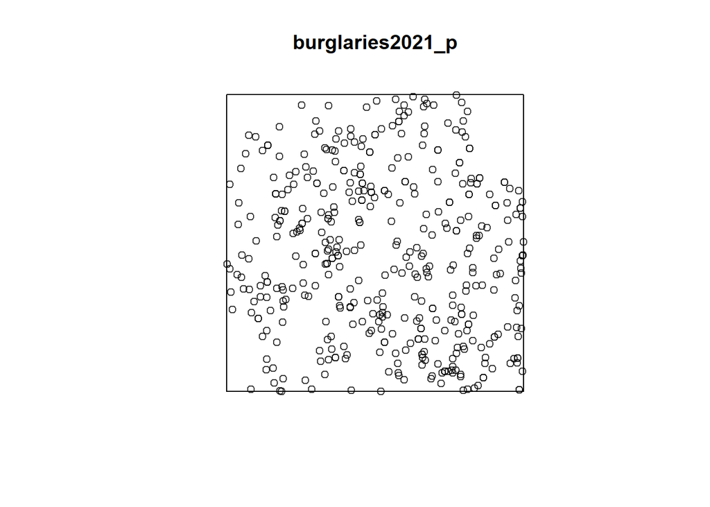

```r
# Check that the point pattern looks right by plotting it:
plot(burglaries2021_p, clipwin = bbox )
```

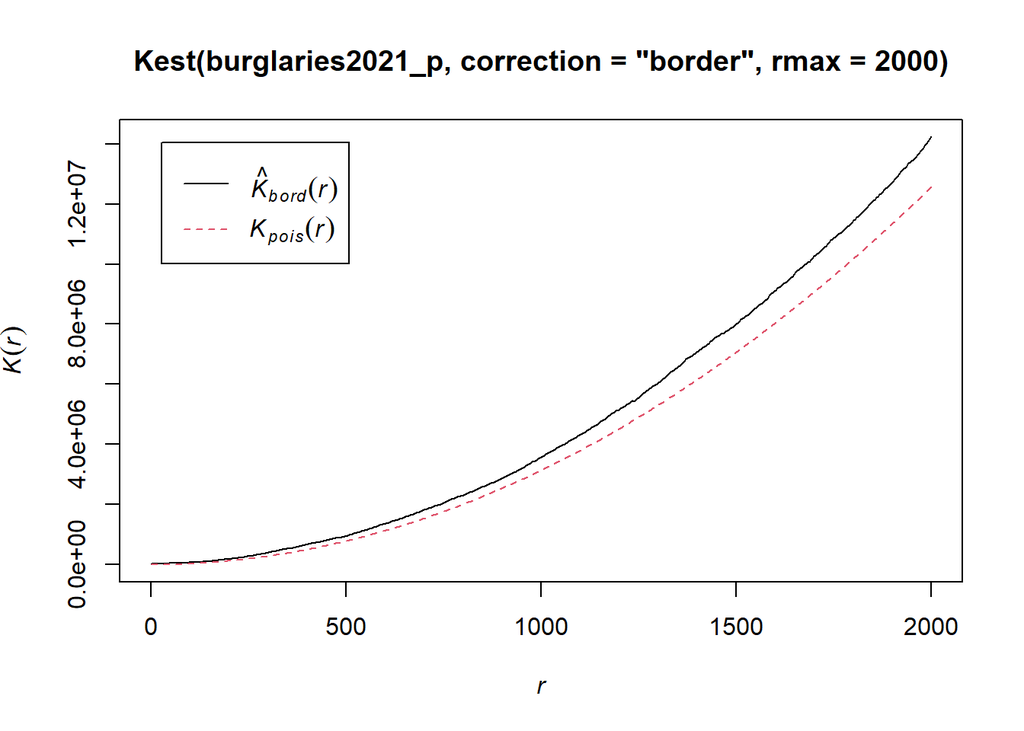

```r
# ripley's K-function with border correction (buffer zone)
# ?Kest to view Help
plot(Kest(burglaries2021_p, correction = "border", rmax = 2000))
```

```
## Generating 99 simulations of CSR  ...
## 1, 2, 3, 4, 5, 6, 7, 8, 9, 10, 11, 12, 13, 14, 15, 16, 17, 18, 19, 20, 21, 22, 23, 24, 25, 26, 27, 28, 29, 30, 31, 32, 33, 34, 35, 36, 37, 38, 39, 40,
## 41, 42, 43, 44, 45, 46, 47, 48, 49, 50, 51, 52, 53, 54, 55, 56, 57, 58, 59, 60, 61, 62, 63, 64, 65, 66, 67, 68, 69, 70, 71, 72, 73, 74, 75, 76, 77, 78, 79, 80,
## 81, 82, 83, 84, 85, 86, 87, 88, 89, 90, 91, 92, 93, 94, 95, 96, 97, 98,  99.
##
## Done.
```

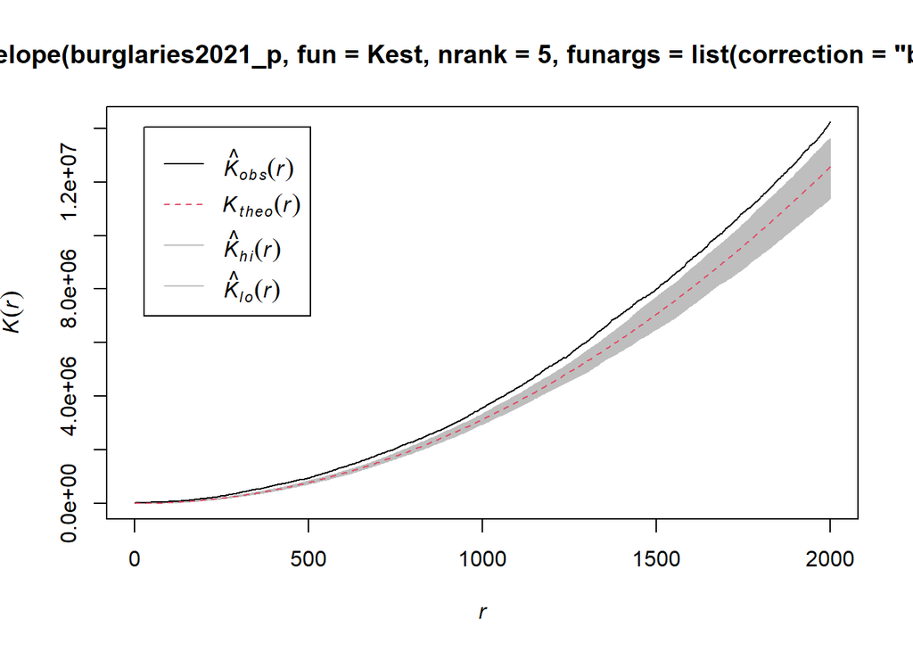

```r
# Envelopes of K-function - top an bottome 5% under CSR:
# ?envelope to view Help
plot(envelope(burglaries2021_p, fun = Kest, nrank = 5, funargs = list(correction = "border", rmax = 2000)))
```

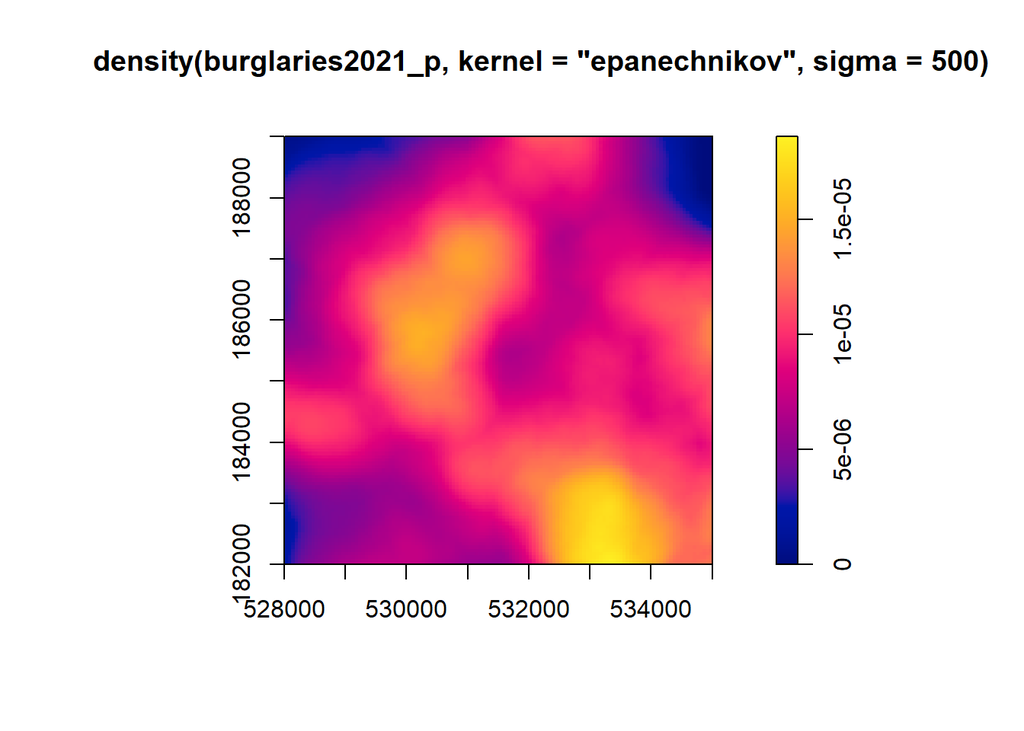

```r
#KERNEL DENSITY

# kernel smoother of point density:
plot(density(burglaries2021_p, kernel = "epanechnikov", sigma = 500), axes = TRUE)
```

## EXTRA:

ploting the points into a map:

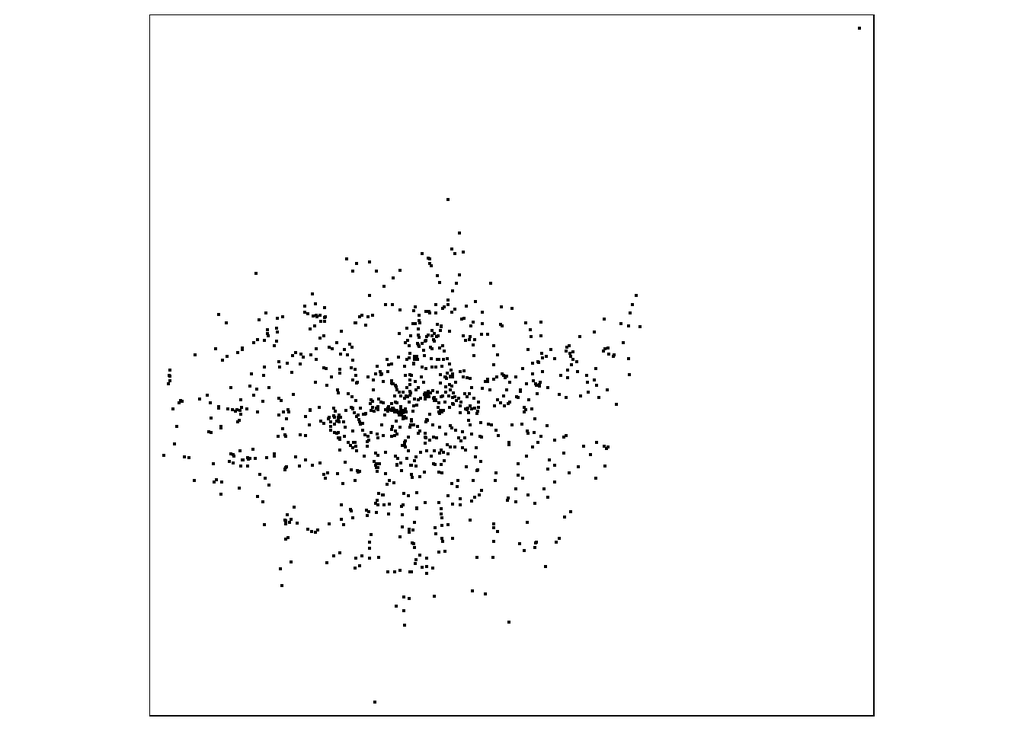

```r
# install.packages("tmap")
library(tmap)

# QTM: Quick TMap:
crimes2021points %>%
  sample_n(1000) %>%
  qtm(basemaps = "Stamen.Watercolor")
```

or the interactive version:

```r
tmap_mode("view") # thsi to activate the interactive version
```

```
## tmap mode set to interactive viewing
```

```r
crimes2021points %>%
  sample_n(1000) %>% # just get a random 1000  observations so the dataset is not too large
  qtm(crimes2021points, basemaps = "Stamen.Watercolor")
```

[interactive chart not shown]